# Modeling and prediction for movies

### Building model

For our next step, let’s create a function that can iterate explanatory variably in the process of creating prediction functions. We going to use **adjusted R2 method** for checking usefulness explanatory variables. That method is more computationally intensive, but it is more reliable then p-value method. Also, **forward-selection method** was chosen for the simplification task.

```r
lm_auto_forvard <- function(lm_data, pred_var, expl_var) {

  iterations <- 1:length(expl_var)
  formula_lm <- paste0(pred_var, ' ~ ')
  adjR2 <- 0

  for (iter in iterations) {
    # find next best variables
    df_best_next_var <- data.frame(var = character(), adjR2 = double(), R2 = double(), stringsAsFactors = FALSE)
    for (v in expl_var) {
      fla <- as.formula(paste(formula_lm,  v, sep = '+'))
      m <- lm(fla, data = lm_data)
      sum_m <- summary(m)
      df_best_next_var[nrow(df_best_next_var) + 1, ] = c(v, sum_m[["adj.r.squared"]], sum_m[["r.squared"]])
    }

    # check adjR2
    best_var <- df_best_next_var %>%
      slice(which.max(adjR2))
    if (best_var$adjR2 < adjR2) {
      break
    }

    # update formula
    adjR2 <- best_var$adjR2
    formula_lm <- paste(formula_lm, best_var$var, sep = '+')

    # update available variables
    vars <- df_best_next_var %>%
      slice(which(var != best_var$var))
    vars <- vars$var
  }

  return(lm(formula_lm, data = lm_data))
}
```

Let’s create our predicting model. We going to include good existing explanatory variables we have from our data set, to find which we will use and in which order.

```r
expl_var = c("title_type", "genre", "mpaa_rating", "studio_mod2",
             "best_pic_nom", "best_pic_win",
             "best_actor_win", "best_actress_win", "best_dir_win")
pred_var = "score_avg"

m_fun <- lm_auto_forvard(lm_data = movies, expl_var = expl_var, pred_var = pred_var)
```

**Model diagnostics**

The function we created shows us all explanatory variables are categorical, it’s not an easy way to check collinearity for that type of data. We going to stay with this uncertainty.

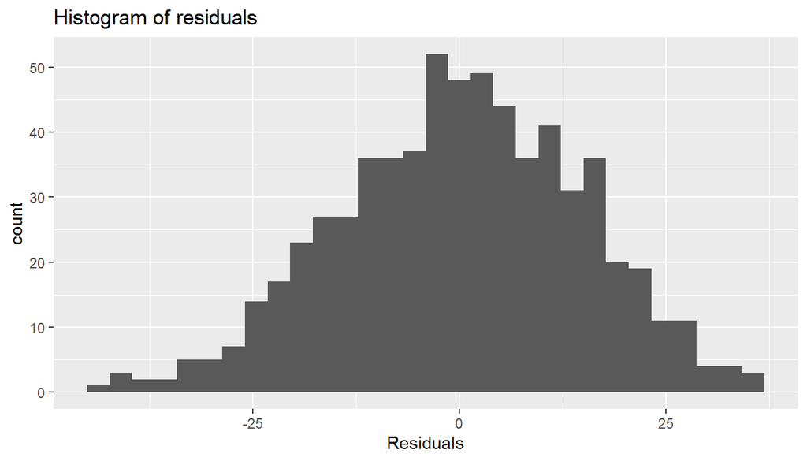

```r
m_fun %>%
  ggplot(aes(x = .resid)) +
  geom_histogram() +
  xlab("Residuals") +
  ggtitle("Histogram of residuals")
```

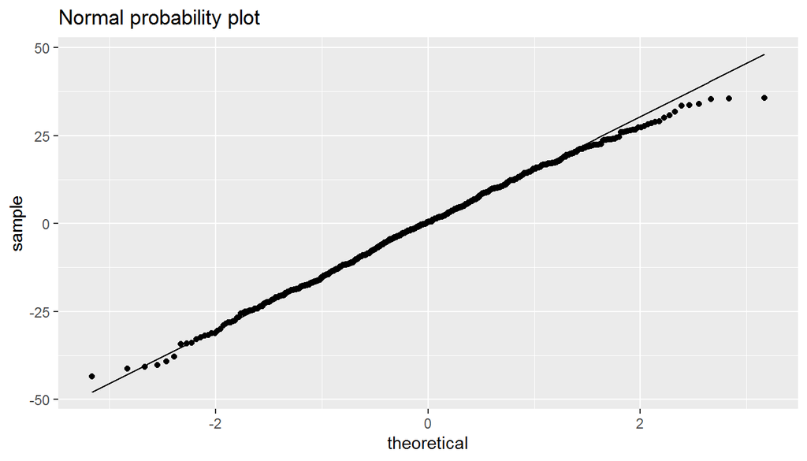

```r
m_fun %>%
  ggplot(aes(sample = .resid)) +
  stat_qq() +
  stat_qq_line() +
  ggtitle("Normal probability plot")
```

Normal probability plot and histogram of residuals shows us nearly normal residuals with mean 0.

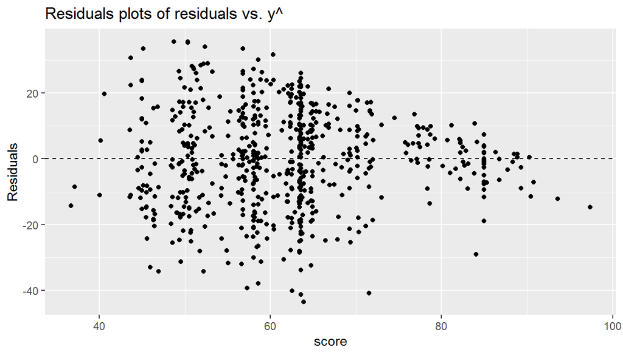

```r
m_fun %>%
  ggplot(aes(x = .fitted, y = .resid)) +
  geom_jitter() +
  geom_hline(yintercept = 0, linetype = "dashed") +
  xlab("score") +
  ylab("Residuals") +
  ggtitle('Residuals plots of residuals vs. y^')
```

Residuals plots of residuals vs. y^ **do not** show us constant variability of residuals. This is something we should be caring about. For low predicting scores, we have wider residual distribution then for high predicting scores.

For next step, let’s get summary output for our model.

```r
summary(m_fun)
```

```
##
## Call:
## lm(formula = formula_lm, data = lm_data)
##
## Residuals:
##     Min      1Q  Median      3Q     Max
## -43.546 -10.153   0.421  10.323  35.630
##
## Coefficients:
##                                        Estimate Std. Error t value Pr(>|t|)
## (Intercept)                             74.0548     7.5611   9.794  < 2e-16 ***
## genreAnimation                           0.8455     6.0024   0.141 0.888031
## genreArt House & International           7.4262     4.6591   1.594 0.111475
## genreComedy                             -0.4653     2.5477  -0.183 0.855143
## genreDocumentary                        10.9838     6.1044   1.799 0.072461 .
## genreDrama                              12.5784     2.1756   5.781 1.18e-08 ***
## genreHorror                             -2.4238     3.8438  -0.631 0.528555
## genreMusical & Performing Arts          19.5520     5.2291   3.739 0.000202 ***
## genreMystery & Suspense                  5.7979     2.8352   2.045 0.041289 *
## genreOther                              12.5047     4.4098   2.836 0.004725 **
## genreScience Fiction & Fantasy          -0.2580     5.4850  -0.047 0.962495
## best_pic_nomyes                         19.1211     3.4229   5.586 3.50e-08 ***
## mpaa_ratingNC-17                         2.1674    11.7085   0.185 0.853199
## mpaa_ratingPG                           -6.4749     4.4934  -1.441 0.150105
## mpaa_ratingPG-13                       -10.8158     4.6433  -2.329 0.020168 *
## mpaa_ratingR                            -5.4506     4.5487  -1.198 0.231275
## mpaa_ratingUnrated                       1.1602     5.1445   0.226 0.821651
## best_dir_winyes                          8.1096     2.4931   3.253 0.001206 **
## title_typeFeature Film                 -16.4164     5.7116  -2.874 0.004192 **
## title_typeTV Movie                     -25.0210     9.1459  -2.736 0.006405 **
## studio_mod2Buena Vista                   0.9398     4.2954   0.219 0.826877
## studio_mod2Columbia Pictures             6.5448     5.0938   1.285 0.199329
## studio_mod2First Run Features           -4.0191     6.7136  -0.599 0.549633
## studio_mod2HBO                           2.6817     5.8322   0.460 0.645819
## studio_mod2IFC Films                     0.5690     4.3674   0.130 0.896391
## studio_mod2Lions Gate Films             -0.3855     4.0649  -0.095 0.924479
## studio_mod2Magnolia Pictures             4.5064     5.1503   0.875 0.381932
## studio_mod2MCA Universal Home Video      3.6035     4.8255   0.747 0.455496
## studio_mod2MGM                          -6.2066     3.6408  -1.705 0.088751 .
## studio_mod2Miramax Films                -2.6942     3.7672  -0.715 0.474775
## studio_mod2New Line Cinema              -9.6836     5.2969  -1.828 0.068012 .
## studio_mod2New Line Home Entertainment  -1.6168     6.2102  -0.260 0.794688
## studio_mod2Orion                        -2.3130     5.1080  -0.453 0.650842
## studio_mod2Others                       -1.2176     2.5276  -0.482 0.630175
## studio_mod2Paramount Pictures           -1.3575     2.9483  -0.460 0.645375
## studio_mod2Sony Pictures                -1.3521     2.9977  -0.451 0.652111
## studio_mod2The Weinstein Company        -1.7299     5.3453  -0.324 0.746329
## studio_mod2Touchstone Pictures           3.0605     7.1870   0.426 0.670371
## studio_mod2United Artists               12.3171     6.7990   1.812 0.070538 .
## studio_mod2Universal Pictures            4.5828     3.7123   1.235 0.217489
## studio_mod2Walt Disney Pictures         10.7846     6.3486   1.699 0.089882 .
## studio_mod2Warner Bros. Pictures         0.1373     2.8061   0.049 0.961004
## ---
## Signif. codes:  0 '***' 0.001 '**' 0.01 '*' 0.05 '.' 0.1 ' ' 1
##
## Residual standard error: 15.17 on 609 degrees of freedom
## Multiple R-squared:  0.3518, Adjusted R-squared:  0.3082
## F-statistic: 8.063 on 41 and 609 DF,  p-value: < 2.2e-16
```

We got the model that has multiple R-squared equal 0.3518. That means that our model predicts roughly 35% of scores variability can be explained by the model, this is not to mush. Also, we can say that we have a very big residual standard error: 15,17. That means that our 95% confidence level would be roughly 60 score points. Which this we should mention that we got pretty low p-value, which means that our model statistical significant.

As we have all categorical explanatory variables, let’s make a quick view whish values of those give us the highest expected score:

- “Musical & Performing Arts” for the genre: roughly 19,5 scores.
- If a movie was nominated for best picture Oscar: roughly 19 scores.
- “NC-17” mpaa_rating gives roughly 2 additional scores.
- The documentary type of movie does not have a penalty.
- Already closes “United Artists” studio would give us roughly 12 scores.

For the next step, let’s check ANOVA output.

```r
anova(m_fun)
```

```
## Analysis of Variance Table
##
## Response: score_avg
##               Df Sum Sq Mean Sq F value    Pr(>F)
## genre         10  49983  4998.3 21.7241 < 2.2e-16 ***
## best_pic_nom   1   9130  9129.6 39.6796 5.736e-10 ***
## mpaa_rating    5   6199  1239.8  5.3885 7.370e-05 ***
## best_dir_win   1   2869  2869.2 12.4702 0.0004448 ***
## title_type     2   2328  1164.0  5.0592 0.0066203 **
## studio_mod2   22   5550   252.3  1.0965 0.3449917
## Residuals    609 140120   230.1
## ---
## Signif. codes:  0 '***' 0.001 '**' 0.01 '*' 0.05 '.' 0.1 ' ' 1
```

We got that **except** `studio_mod2` variable all other variables are statistically significant. Return to our beginning questions we can say that our model does not get statistical significant evidence about the relationship between famous “actress/actor” or “studio” and “average move score”.

Practically, we got that including in moves adult material is relevant for expected move score, and in our model that variable describes roughly 3% (6199/(49983+9130+6199+2869+2328+5550+140120) = 0.02867531). And studio describes 2,5% of expected movie score.

## Part 5: Prediction

Let’s make a prediction for “Ford v Ferrari” (2019) movie and compare the result with the average current rating. The data about movie we got from [imdb.com](https://www.imdb.com/title/tt1950186/) and [rottentomatoes.com](https://www.rottentomatoes.com/m/ford_v_ferrari), information about director from [wikipedia.org](https://en.wikipedia.org/wiki/James_Mangold).

```r
ford_v_ferrari <- data.frame(genre = "Drama",
                      best_pic_nom = "yes",
                      mpaa_rating = "PG-13",
                      best_dir_win = "yes",
                      title_type = "Feature Film",
                      studio_mod2 = "20th Century Fox")

predict(m_fun, ford_v_ferrari, interval = "prediction", level = 0.95)
```

```
##       fit      lwr      upr
## 1 86.6318 55.55224 117.7114
```

We got pretty hight expected scores, let’s check current ratings:

```r
imdb_rating <- 8.1
critics_score <- 92
audience_score <- 98

score_avg <- (imdb_rating*10 + critics_score  + audience_score)/3
print(paste0("Curent averege score for 'Ford v Ferrari' is ", round(score_avg,1) ))
```

```
## [1] "Curent averege score for 'Ford v Ferrari' is 90.3"
```

Hence, the model predicts, with 95% confidence, that “Ford v Ferrari” is expected to have an evaluation score between 55.5 and 100. Also, we can mention that for that specific case we got a much more accurate result than we expected on average.